# ProjectEx1_319000725_207036211

```python
import pandas as pd
import numpy as np
import seaborn as sns
import matplotlib.dates as mdates
from statsmodels.tsa.seasonal import seasonal_decompose
from statsmodels.graphics import tsaplots
from statsmodels.tsa.statespace.sarimax import SARIMAX
from statsmodels.tsa.holtwinters import SimpleExpSmoothing
from statsmodels.tsa.holtwinters import ExponentialSmoothing
from prophet import Prophet
from scipy import stats
from statsmodels.graphics.tsaplots import plot_acf
from statsmodels.tsa.holtwinters import ExponentialSmoothing
from sklearn.linear_model import LinearRegression
from sklearn.metrics import mean_squared_error, mean_absolute_error, mean_absolute_percentage_error
from sklearn.preprocessing import MinMaxScaler
from matplotlib import pyplot as plt
```

### Part 1- pre-processing:

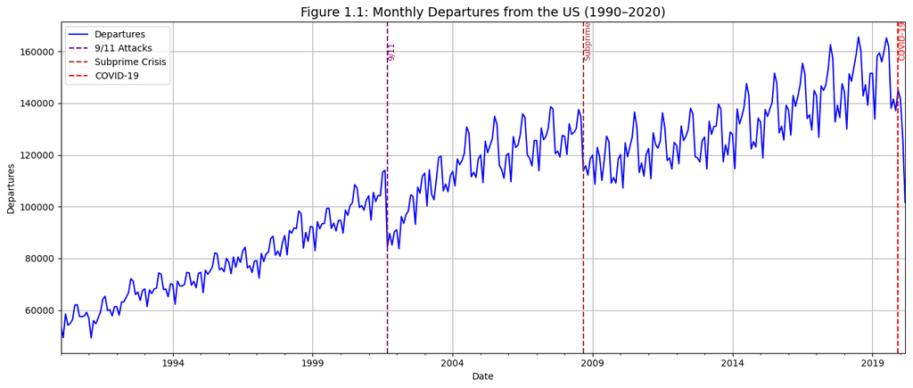

```python
# Load the dataset
df = pd.read_csv("DataProjectEX1_319000725_207036211.csv", parse_dates=['date'])

# Sort by date and set as index
df = df.sort_values('date').set_index('date')

# Plot the departures series with key events
plt.figure(figsize=(14, 6))
df['Departures'].plot(color='blue', label='Departures')

# Add key event markers
plt.axvline(pd.Timestamp("2001-09-01"), color='purple', linestyle='--', label='9/11 Attacks')
plt.axvline(pd.Timestamp("2008-09-01"), color='brown', linestyle='--', label='Subprime Crisis')
plt.axvline(pd.Timestamp("2019-12-01"), color='red', linestyle='--', label='COVID-19')

# Add labels near the lines
plt.text(pd.Timestamp("2001-09-01"), df['Departures'].max()*0.95, '9/11', color='purple', rotation=90, fontsize=9)
plt.text(pd.Timestamp("2008-09-01"), df['Departures'].max()*0.95, 'Subprime', color='brown', rotation=90, fontsize=9)
plt.text(pd.Timestamp("2019-12-01"), df['Departures'].max()*0.95, 'COVID-19', color='red', rotation=90, fontsize=9)

# Title and axes
plt.title("Figure 1.1: Monthly Departures from the US (1990–2020)", fontsize=14)
plt.xlabel("Date")
plt.ylabel("Departures")
plt.grid(True)
plt.legend(loc='upper left')
plt.tight_layout()
plt.show()

# Prepare the main time series for future use
monthly_departures = df[['Departures']].copy()
```

```python
print(monthly_departures.isna().sum())        # count NaNs
print(monthly_departures.index.is_unique)     # does the dates are unique?
monthly_departures
```

```
Departures    0
dtype: int64
True
```

| date | Departures |
| --- | --- |
| 1990-01-01 | 54129 |
| 1990-02-01 | 49391 |
| 1990-03-01 | 58542 |
| 1990-04-01 | 54195 |
| 1990-05-01 | 54863 |
| ... | ... |
| 2019-11-01 | 137130 |
| 2019-12-01 | 145140 |
| 2020-01-01 | 141636 |
| 2020-02-01 | 126629 |
| 2020-03-01 | 101676 |

363 rows × 1 columns

```python
min_val = monthly_departures.min()
max_val = monthly_departures.max()
min_date = monthly_departures.idxmin()
max_date = monthly_departures.idxmax()

print(f" min flights: {min_val} at date {min_date}")
print(f" maximum: {max_val} at date {max_date}")
```

```
 min flights: Departures    49264
dtype: int64 at date Departures   1991-02-01
dtype: datetime64[ns]
 maximum: Departures    165616
dtype: int64 at date Departures   2018-07-01
dtype: datetime64[ns]
```

To improve model stability and interpretability, we scaled down the number of monthly departures by a constant factor. Working with extremely large values can introduce numerical instability or affect model sensitivity. In addition, we excluded all data points after December 2019, since the COVID-19 pandemic significantly disrupted air travel patterns. Including this period would introduce an abrupt shift in the trend with no recovery data afterward, making it difficult for the model to learn meaningful patterns and forecast accurately.

```python
monthly_departures = monthly_departures[monthly_departures.index <= '2019-12']
monthly_departures = monthly_departures / 1000
monthly_departures
```

| date | Departures |
| --- | --- |
| 1990-01-01 | 54.129 |
| 1990-02-01 | 49.391 |
| 1990-03-01 | 58.542 |
| 1990-04-01 | 54.195 |
| 1990-05-01 | 54.863 |
| ... | ... |
| 2019-08-01 | 161.743 |
| 2019-09-01 | 138.071 |
| 2019-10-01 | 141.560 |
| 2019-11-01 | 137.130 |
| 2019-12-01 | 145.140 |

360 rows × 1 columns

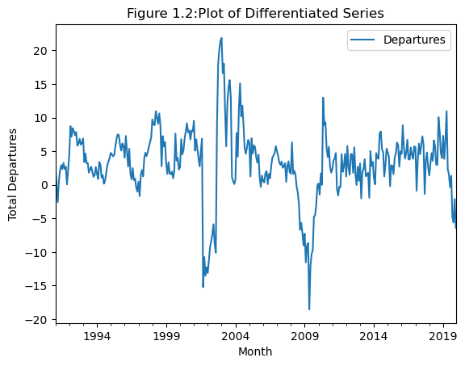

```python
#Substract seasonality by using differncing
data_without_seasonality = monthly_departures.diff(periods=12)
data_without_seasonality = data_without_seasonality.dropna()
#Plot the transformed data
data_without_seasonality.plot()
plt.title("Figure 1.2:Plot of Differentiated Series")
plt.xlabel("Month")
plt.ylabel("Total Departures")
```

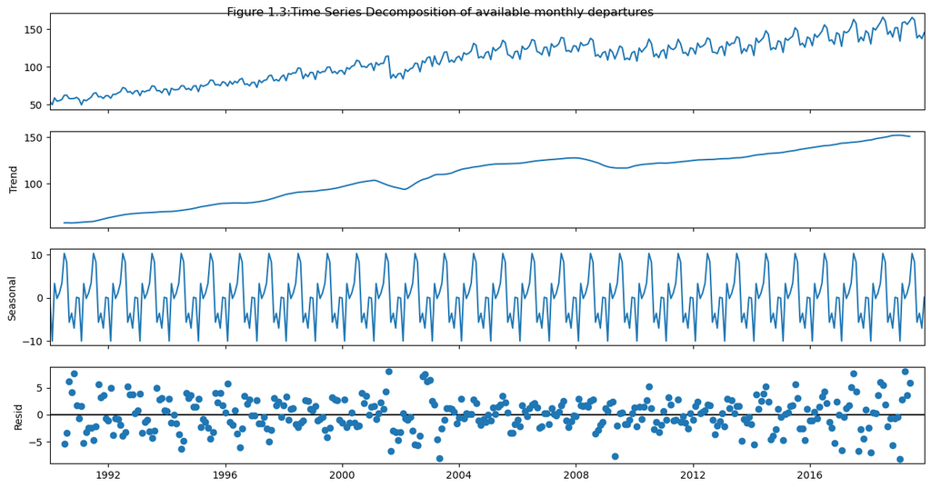

```python
# Decompose the time series into trend, seasonal, and residual components
decomposition = seasonal_decompose(monthly_departures, model='additive', period=12)

# Plot the decomposed components
fig = decomposition.plot()
fig.set_size_inches(14, 7)
plt.suptitle('Figure 1.3:Time Series Decomposition of available monthly departures')
plt.show()
```

### Part 2-model fitting

### Sarima models:

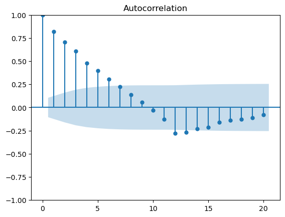

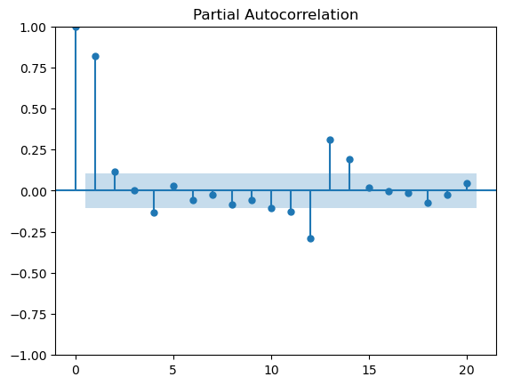

```python
#Plotting the autocorrelation for the new series
tsaplots.plot_acf(data_without_seasonality, lags=20)
tsaplots.plot_pacf(data_without_seasonality, lags=20)
plt.show()
```

```python
#SARIMA(1,0,0)(0,1,0)_{s=12}
model_AR1 = SARIMAX(monthly_departures, order=(1,0,0), seasonal_order=(0,1,0,12))
model_AR1 = model_AR1.fit(disp=False)
```

```python
#SARIMA(1,0,0)(1,1,0)_{s=12}
model_AR1s = SARIMAX(monthly_departures, order=(1,0,0), seasonal_order=(1,1,0,12))
model_AR1s = model_AR1s.fit(disp=False)
```

```python
#SARIMA(2,0,0)(0,1,0)_{s=12}
model_AR2 = SARIMAX(monthly_departures, order=(2,0,0), seasonal_order=(0,1,0,12))
model_AR2 = model_AR2.fit(disp=False)
```

```python
#SARIMA(2,0,0)(1,1,0)_{s=12}
model_AR2s = SARIMAX(monthly_departures, order=(2,0,0), seasonal_order=(1,1,0,12))
model_AR2s = model_AR2s.fit(disp=False)
```

```python
#Check the models BICs
print(f'Model AR1 BIC is : {model_AR1.bic}')
print(f'Model AR1s BIC is : {model_AR1s.bic}')
print(f'Model AR2 BIC is : {model_AR2.bic}')
print(f'Model AR2s BIC is : {model_AR2s.bic}')
```

```
Model AR1 BIC is : 1776.1815708396514
Model AR1s BIC is : 1705.5624254589086
Model AR2 BIC is : 1775.7336733704471
Model AR2s BIC is : 1695.6211018842894
```

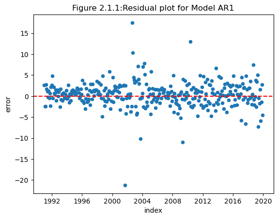

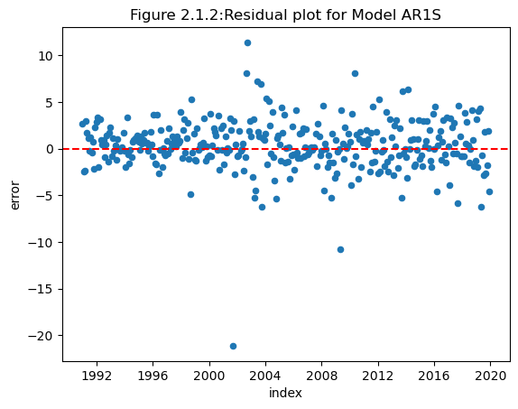

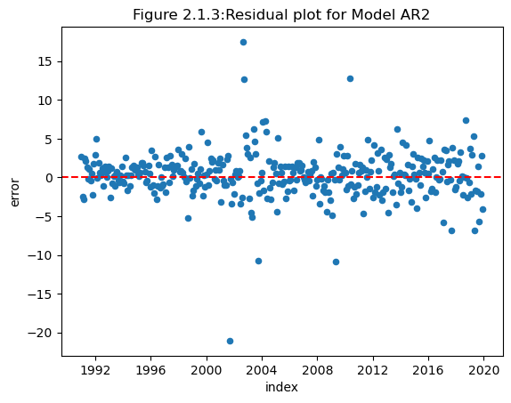

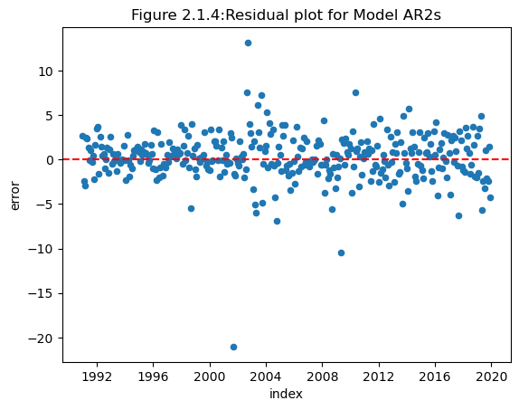

```python
#Plot residual plots for every model

#Model AR1
res_plot = pd.DataFrame(model_AR1.resid.iloc[12:], columns = ['error'])
res_plot['index'] = res_plot.index
res_plot.plot.scatter(x='index', y="error")
plt.axhline(y=0, color="red", linestyle="--")
plt.title("Figure 2.1.1:Residual plot for Model AR1")
plt.show()

#Model AR1S
res_plot = pd.DataFrame(model_AR1s.resid.iloc[12:], columns = ['error'])
res_plot['index'] = res_plot.index
res_plot.plot.scatter(x='index', y="error")
plt.axhline(y=0, color="red", linestyle="--")
plt.title("Figure 2.1.2:Residual plot for Model AR1S")
plt.show()

#Model AR2
res_plot = pd.DataFrame(model_AR2.resid.iloc[12:], columns = ['error'])
res_plot['index'] = res_plot.index
res_plot.plot.scatter(x='index', y="error")
plt.axhline(y=0, color="red", linestyle="--")
plt.title("Figure 2.1.3:Residual plot for Model AR2")
plt.show()

#Model AR2s
res_plot = pd.DataFrame(model_AR2s.resid.iloc[12:], columns = ['error'])
res_plot['index'] = res_plot.index
res_plot.plot.scatter(x='index', y="error")
plt.axhline(y=0, color="red", linestyle="--")
plt.title("Figure 2.1.4:Residual plot for Model AR2s")
plt.show()
```

As we can see, the fourth model SARIMA(2,0,0)(1,1,0)*{s=12} , is a better fit and it has a lower BIC.All the models have pretty much the same residuals , so we will choose SARIMA(2,0,0)(1,1,0)*{s=12} as the best model.

```python
print(model_AR2s.summary())
```

```
                                     SARIMAX Results
==========================================================================================
Dep. Variable:                         Departures   No. Observations:                  360
Model:             SARIMAX(2, 0, 0)x(1, 1, 0, 12)   Log Likelihood                -836.106
Date:                            Sat, 05 Apr 2025   AIC                           1680.212
Time:                                    15:18:58   BIC                           1695.621
Sample:                                01-01-1990   HQIC                          1686.347
                                     - 12-01-2019
Covariance Type:                              opg
==============================================================================
                 coef    std err          z      P>|z|      [0.025      0.975]
------------------------------------------------------------------------------
ar.L1          0.7257      0.043     16.846      0.000       0.641       0.810
ar.L2          0.2128      0.043      4.982      0.000       0.129       0.296
ar.S.L12      -0.4863      0.027    -17.843      0.000      -0.540      -0.433
sigma2         7.0544      0.225     31.375      0.000       6.614       7.495
===================================================================================
Ljung-Box (L1) (Q):                   0.18   Jarque-Bera (JB):              2750.06
Prob(Q):                              0.67   Prob(JB):                         0.00
Heteroskedasticity (H):               2.40   Skew:                            -1.34
Prob(H) (two-sided):                  0.00   Kurtosis:                        16.51
===================================================================================

Warnings:
[1] Covariance matrix calculated using the outer product of gradients (complex-step).
```

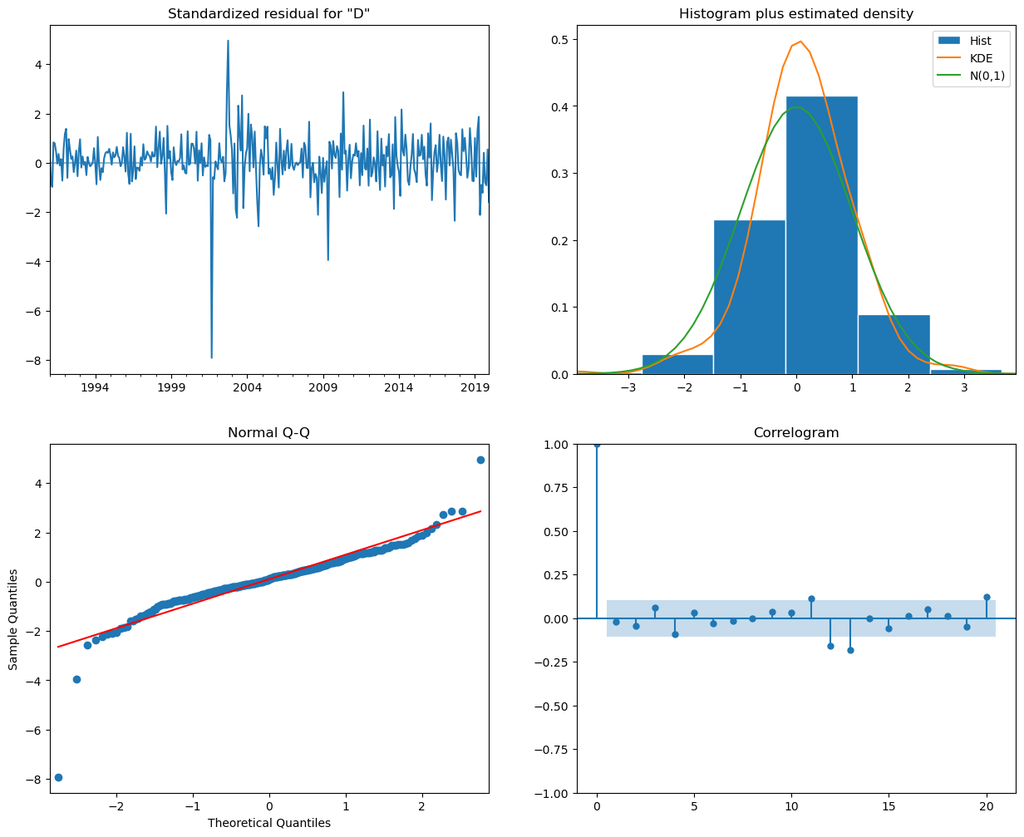

```python
#Plot diagnostics
model_AR2s.plot_diagnostics(lags=20,figsize=(15, 12))
plt.show()
```

```python
# Forecast 60 steps ahead
forecast_steps = 60
forecast_result = model_AR2s.get_forecast(steps=forecast_steps)

# Get predicted mean and confidence intervals
forecast_mean = forecast_result.predicted_mean
conf_int = forecast_result.conf_int()
```

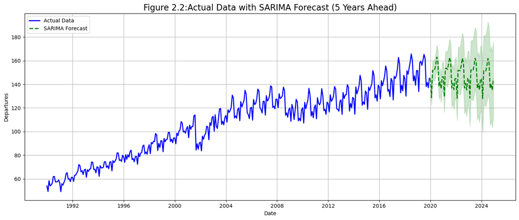

```python
plt.figure(figsize=(14, 6))
monthly_departures.index = pd.to_datetime(monthly_departures.index)

# Plot actual data
plt.plot(monthly_departures, label='Actual Data', color='blue', linewidth=2)

# Plot forecast
forecast_index = pd.date_range(start=monthly_departures.index[-1] + pd.offsets.MonthBegin(1),
                               periods=forecast_steps, freq='MS')

plt.plot(forecast_index, forecast_mean, label='SARIMA Forecast', color='green', linestyle='--', linewidth=2)

# Confidence interval
plt.fill_between(forecast_index,
                 conf_int.iloc[:, 0],
                 conf_int.iloc[:, 1],
                 color='green', alpha=0.2)

# Labels
plt.title('Figure 2.2:Actual Data with SARIMA Forecast (5 Years Ahead)', fontsize=16)
plt.xlabel('Date')
plt.ylabel('Departures')
plt.legend()
plt.grid(True)
plt.tight_layout()
plt.show()
```

### Propthet model:

```python
df_prophet = monthly_departures.reset_index()
df_prophet.columns = ['ds', 'y']

df_prophet['ds'] = pd.to_datetime(df_prophet['ds'])

print(df_prophet.head())
```

```
          ds       y
0 1990-01-01  54.129
1 1990-02-01  49.391
2 1990-03-01  58.542
3 1990-04-01  54.195
4 1990-05-01  54.863
```

```python
model_p = Prophet(daily_seasonality=False, weekly_seasonality=False, yearly_seasonality=True)
model_p.fit(df_prophet)
```

```
15:19:00 - cmdstanpy - INFO - Chain [1] start processing
15:19:00 - cmdstanpy - INFO - Chain [1] done processing
```

```
<prophet.forecaster.Prophet at 0x13f62dd05c0>
```

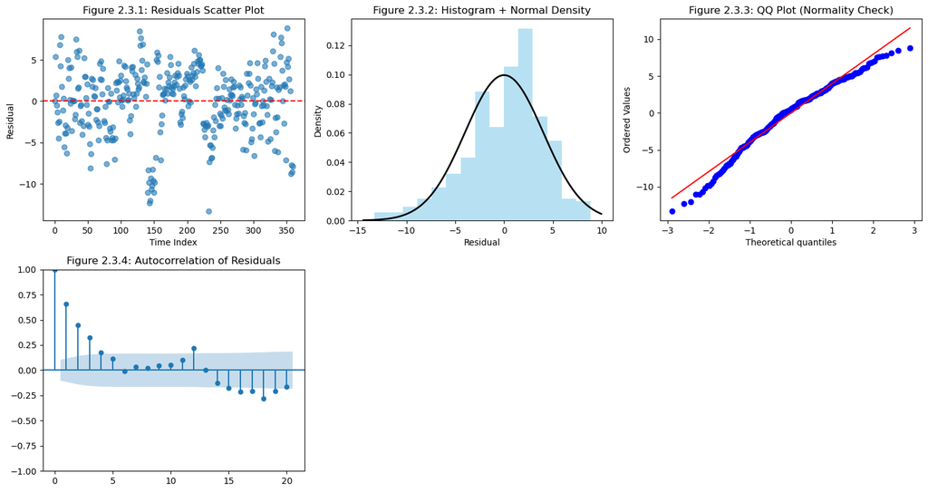

```python
# Create residuals between actual and predicted values
actual = monthly_departures['Departures'].values
future_df = model_p.make_future_dataframe(periods=365)
forecast_df = model_p.predict(future_df)
predicted = forecast_df['yhat'].iloc[:len(actual)].values
residuals = actual - predicted

# Plot diagnostics
plt.figure(figsize=(15, 8))

# Plot 1: Residuals scatter plot
plt.subplot(231)
plt.scatter(range(len(residuals)), residuals, alpha=0.6)
plt.axhline(0, color='red', linestyle='--')
plt.title('Figure 2.3.1: Residuals Scatter Plot')
plt.xlabel('Time Index')
plt.ylabel('Residual')

# Plot 2: Histogram with normal distribution overlay
plt.subplot(232)
plt.hist(residuals, bins=15, density=True, alpha=0.6, color='skyblue')
xmin, xmax = plt.xlim()
x = np.linspace(xmin, xmax, 100)
pdf = stats.norm.pdf(x, np.mean(residuals), np.std(residuals))
plt.plot(x, pdf, 'k', linewidth=2)
plt.title('Figure 2.3.2: Histogram + Normal Density')
plt.xlabel('Residual')
plt.ylabel('Density')

# Plot 3: QQ Plot to check normality
plt.subplot(233)
stats.probplot(residuals, dist="norm", plot=plt)
plt.title('Figure 2.3.3: QQ Plot (Normality Check)')

# Plot 4: Autocorrelation of residuals
plt.subplot(234)
plot_acf(residuals, ax=plt.gca(), lags=20)
plt.title('Figure 2.3.4: Autocorrelation of Residuals')

plt.tight_layout()
plt.show()
```

### Frocast with prophet:

```python
# Get the last date in your actual data
last_date = monthly_departures.index.max()

# Forecast 5 years ahead (60 months)
future = model_p.make_future_dataframe(periods=60, freq='MS')
forecast = model_p.predict(future)

# Take only the future part of the forecast
forecast_future = forecast[forecast['ds'] > last_date]
```

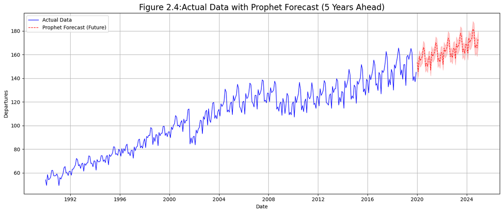

```python
# Actual data
plt.figure(figsize=(14, 6))

plt.plot(monthly_departures.index, monthly_departures.values,
         label='Actual Data', color='blue', linewidth=1)

# Forecast line (only future)
plt.plot(forecast_future['ds'], forecast_future['yhat'],
         label='Prophet Forecast (Future)', color='red', linewidth=1, linestyle='--')

# Confidence interval
plt.fill_between(forecast_future['ds'],
                 forecast_future['yhat_lower'],
                 forecast_future['yhat_upper'],
                 color='red', alpha=0.2)

# Labels & styling
plt.title("Figure 2.4:Actual Data with Prophet Forecast (5 Years Ahead)", fontsize=16)
plt.xlabel("Date")
plt.ylabel("Departures")
plt.legend()
plt.grid(True)
plt.tight_layout()
plt.show()
```

### Exponential Smoothing with Holt winters:

```python
monthly_departures.index = pd.to_datetime(monthly_departures.index)
monthly_departures = monthly_departures.asfreq('MS')

# Fit Exponential Smoothing model with trend and seasonality
model = ExponentialSmoothing(
    monthly_departures,
    trend='add',
    seasonal='add',
    seasonal_periods=12 )

fit = model.fit()

forecast_steps = 60
forecast_index = pd.date_range(start=monthly_departures.index[-1] + pd.offsets.MonthBegin(1),
                               periods=forecast_steps, freq='MS')

forecast = fit.forecast(forecast_steps)
forecast.index = forecast_index
```

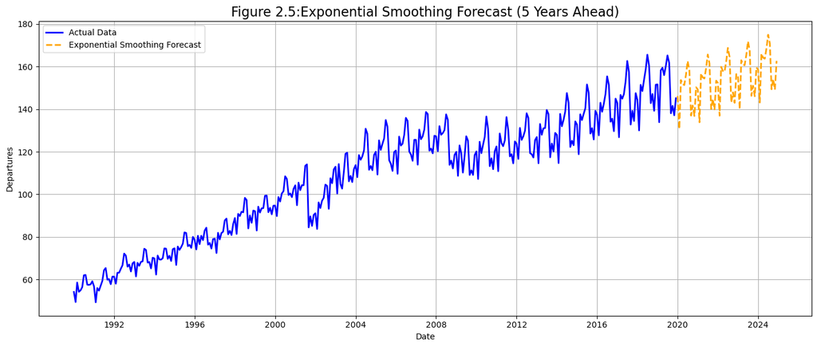

```python
plt.figure(figsize=(14, 6))

# Original data
plt.plot(monthly_departures, label='Actual Data', linewidth=2, color='blue')

# Forecast
plt.plot(forecast, label='Exponential Smoothing Forecast', linewidth=2, color='orange', linestyle='--')

plt.title('Figure 2.5:Exponential Smoothing Forecast (5 Years Ahead)', fontsize=16)
plt.xlabel('Date')
plt.ylabel('Departures')
plt.legend()
plt.grid(True)
plt.tight_layout()
plt.show()
```

### Forcast with fourier

```python
rng = pd.date_range(start = '1990-01-01', end = '2019-12-01', freq='MS')
monthly_departures.set_index(rng, inplace=True) #change index to dates.
monthly_departures.head()
```

|  | Departures |
| --- | --- |
| 1990-01-01 | 54.129 |
| 1990-02-01 | 49.391 |
| 1990-03-01 | 58.542 |
| 1990-04-01 | 54.195 |
| 1990-05-01 | 54.863 |

```python
slope = (
    monthly_departures['Departures'].iloc[-1] -
    monthly_departures['Departures'].iloc[0]
) / (len(monthly_departures) - 1)
slope
```

```
0.2535125348189415
```

```python
trend_values = np.zeros(len(monthly_departures))
for i in range(len(monthly_departures)):
    trend_values[i] = slope * i
```

```python
monthly_departures['value'] = monthly_departures['Departures'] - trend_values
```

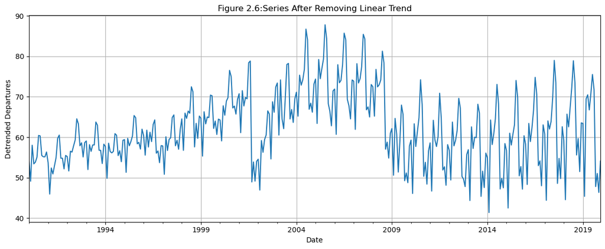

```python
monthly_departures['value'].plot(figsize=(12, 5))
plt.title("Figure 2.6:Series After Removing Linear Trend")
plt.xlabel("Date")
plt.ylabel("Detrended Departures")
plt.grid(True)
plt.tight_layout()
plt.show()
```

As a first step, we attempted to remove a global linear trend from the time series in order to isolate its seasonal component. However, as seen in the detrended series, this approach fails to fully capture the structure of the data. The resulting series still exhibits visible shifts in trend and variability, suggesting that a single linear trend is insufficient. These structural changes, likely due to real-world events, indicate the presence of multiple trend segments over time. To better handle these breaks and to more accurately model the recurring seasonal behavior, we turn to a regression framework that combines Fourier terms with piecewise linear trends. This allows us to flexibly account for both seasonal dynamics and non-uniform trend changes in the data.

```python
monthly_departures.index = pd.to_datetime(monthly_departures.index)

monthly_departures = monthly_departures.sort_index()

monthly_departures['t'] = np.arange(len(monthly_departures))

X_linear = np.array([np.ones(len(monthly_departures)), monthly_departures['t']]).T
X_linear[:5]
```

```
array([[1., 0.],
       [1., 1.],
       [1., 2.],
       [1., 3.],
       [1., 4.]])
```

```python
# Define the train-test split
split_ratio = 0.8 # 80% for training, 20% for testing
# Calculate the split index
split_index = int(len(monthly_departures) * split_ratio)
# Split the data
train_df = monthly_departures.iloc[:split_index]
train_y = train_df['Departures']
test_df = monthly_departures.iloc[split_index:]
test_y = test_df['Departures']
```

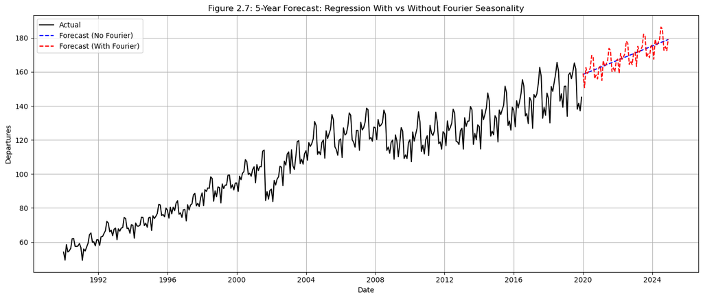

```python
t = np.arange(len(monthly_departures))
monthly_departures['t'] = t

# Generate X_linear = bias + t
X_linear = np.column_stack([np.ones(len(t)), t])

# Shocks: 2001 and 2008
shock_2001_slope = np.array([min(int(i >= 141) * (i - 141), 2) for i in t])
shock_2008_slope = np.array([min(int(i >= 225) * (i - 225), 2) for i in t])
X_shocks = np.column_stack([shock_2001_slope, shock_2008_slope])

# Fourier terms: K=6
lambdas = 2 * np.pi * np.arange(1, 7) / 12
X_seasonality = np.array([
    np.concatenate([np.cos(lambdas * ti), np.sin(lambdas * ti)])
    for ti in t
])

# Define basic and extended X matrices
X_basic = np.concatenate([X_linear, X_shocks], axis=1)
X_extra = np.concatenate([X_linear, X_seasonality, X_shocks], axis=1)

# y: target variable (monthly departures)
y = monthly_departures['Departures']

# Train/test split
split_index = int(len(monthly_departures) * 0.8)
Xb_train, Xb_test = X_basic[:split_index], X_basic[split_index:]
Xe_train, Xe_test = X_extra[:split_index], X_extra[split_index:]
y_train, y_test = y[:split_index], y[split_index:]

# Train linear regression models
model_basic = LinearRegression().fit(Xb_train, y_train)
model_fourier = LinearRegression().fit(Xe_train, y_train)

# Forecast horizon – 5 years
future_steps = 60
t_last = t[-1]
t_future = np.arange(t_last + 1, t_last + future_steps + 1)

# Create future features
X_linear_future = np.column_stack([np.ones(len(t_future)), t_future])
shock_2001_future = np.array([min(int(i >= 141) * (i - 141), 2) for i in t_future])
shock_2008_future = np.array([min(int(i >= 225) * (i - 225), 2) for i in t_future])
X_shocks_future = np.column_stack([shock_2001_future, shock_2008_future])
X_fourier_future = np.array([
    np.concatenate([np.cos(lambdas * ti), np.sin(lambdas * ti)])
    for ti in t_future
])
X_basic_future = np.concatenate([X_linear_future, X_shocks_future], axis=1)
X_extra_future = np.concatenate([X_linear_future, X_fourier_future, X_shocks_future], axis=1)

# Forecasting
forecast_basic = model_basic.predict(X_basic_future)
forecast_fourier = model_fourier.predict(X_extra_future)

# Generate future date range
start_date = monthly_departures.index[-1] + pd.offsets.MonthBegin(1)
future_dates = pd.date_range(start=start_date, periods=future_steps, freq='MS')

# Plot
plt.figure(figsize=(14, 6))
plt.plot(monthly_departures.index, monthly_departures['Departures'], label="Actual", color='black')
plt.plot(future_dates, forecast_basic, label="Forecast (No Fourier)", linestyle='--', color='blue')
plt.plot(future_dates, forecast_fourier, label="Forecast (With Fourier)", linestyle='--', color='red')
plt.title("Figure 2.7: 5-Year Forecast: Regression With vs Without Fourier Seasonality")
plt.xlabel("Date")
plt.ylabel("Departures")
plt.legend()
plt.grid(True)
plt.tight_layout()
plt.show()
```

### Comparison between the performance of the models: train-test split

We used two evaluation metrics: MSE and MAPE. MSE responds more strongly to large errors due to the squaring of residuals, making it particularly useful for identifying models that tend to produce significant deviations. On the other hand, MAPE expresses errors as a percentage of the actual values. Since our dataset contains large values and no zeros, MAPE can be safely used and provides a reliable measure of the relative distance between the forecasts and the actual outcomes

```python
# Define the train-test split
split_ratio = 0.8 # 80% for training, 20% for testing
# Calculate the split index
split_index = int(len(monthly_departures) * split_ratio)
# Split the data
train_df = monthly_departures.iloc[:split_index]
train_y = train_df['Departures']
test_df = monthly_departures.iloc[split_index:]
test_y = test_df['Departures']
print(test_y)
```

```
2014-01-01    127.946
2014-02-01    114.671
2014-03-01    137.781
2014-04-01    131.974
2014-05-01    134.887
               ...
2019-08-01    161.743
2019-09-01    138.071
2019-10-01    141.560
2019-11-01    137.130
2019-12-01    145.140
Freq: MS, Name: Departures, Length: 72, dtype: float64
```

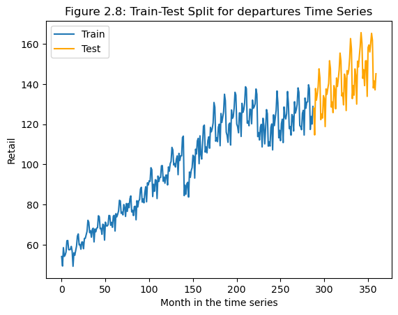

```
Train Data Shape: (288, 3)
Test Data Shape: (72, 3)
```

```python
# Plot the train-test split
plt.plot(np.arange(len(train_df)), train_df['Departures'], label='Train')
plt.plot(np.arange(len(train_df), len(monthly_departures)), test_df['Departures'], label='Test', color='orange')
plt.xlabel('Month in the time series')
plt.ylabel('Retail')
plt.title('Figure 2.8: Train-Test Split for departures Time Series')
plt.legend()
plt.show()
# Print shapes of splits
print("Train Data Shape:", train_df.shape)
print("Test Data Shape:", test_df.shape)
```

```python
# Training and forecasting functions for each model
def train_predict_sarima(train_y, test_y):
    model = SARIMAX(train_y, order=(2, 0, 0), seasonal_order=(1, 1, 0, 12))
    fitted = model.fit(disp=False)
    forecast = fitted.forecast(steps=len(test_y))
    mse = mean_squared_error(test_y, forecast)
    mape = mean_absolute_percentage_error(test_y, forecast) * 100
    return forecast, mse, mape

def train_predict_expsmooth(train_y, test_y):
    model = ExponentialSmoothing(train_y, trend='add', seasonal='add', seasonal_periods=12)
    fitted = model.fit()
    forecast = fitted.forecast(steps=len(test_y))
    mse = mean_squared_error(test_y, forecast)
    mape = mean_absolute_percentage_error(test_y, forecast) * 100
    return forecast, mse, mape

def train_predict_prophet(prophet_df, test_len, test_y):
    model = Prophet(daily_seasonality=False, weekly_seasonality=False, yearly_seasonality=True)
    model.fit(prophet_df)
    future = model.make_future_dataframe(periods=test_len, freq='MS')
    forecast = model.predict(future)
    y_hat = forecast['yhat'].iloc[-test_len:].values
    mse = mean_squared_error(test_y, y_hat)
    mape = mean_absolute_percentage_error(test_y, y_hat) * 100
    return y_hat, mse, mape

# Model to run
models_names_list = ["Sarima", "ExponentialSmoothing", "Prophet"]
models = {}
MSE = {}
MAPE = {}
y_preds = {}
prophet_trained_model = None  # Placeholder to store the trained Prophet model

# Create dataframe for Prophet
prophet_df = monthly_departures.reset_index().rename(columns={
    'year_month': 'ds', 'Departures': 'y'
})
prophet_df = prophet_df[['index', 'y']].rename(columns={'index': 'ds'})

prophet_df['ds'] = pd.to_datetime(prophet_df['ds'])

prophet_train_df = prophet_df.iloc[:split_index]
prophet_test_df = prophet_df.iloc[split_index:]

def train_predict_sarima(train_y, test_y):
    model = SARIMAX(train_y, order=(2, 0, 0), seasonal_order=(1, 1, 0, 12))
    fitted = model.fit(disp=False)
    forecast = fitted.forecast(steps=len(test_y))
    mse = mean_squared_error(test_y, forecast)
    mape = mean_absolute_percentage_error(test_y, forecast) * 100
    return forecast, mse, mape

def train_predict_expsmooth(train_y, test_y):
    model = ExponentialSmoothing(train_y, trend='add', seasonal='add', seasonal_periods=12)
    fitted = model.fit()
    forecast = fitted.forecast(steps=len(test_y))
    mse = mean_squared_error(test_y, forecast)
    mape = mean_absolute_percentage_error(test_y, forecast) * 100
    return forecast, mse, mape

def train_predict_prophet(train_df, test_len, test_y):
    model = Prophet(
        daily_seasonality=False,
        weekly_seasonality=False,
        yearly_seasonality=True
    )
    model.fit(prophet_train_df)
    future = model.make_future_dataframe(periods=test_len, freq='MS')
    forecast = model.predict(future)
    y_hat = forecast['yhat'].iloc[-test_len:].values
    mse = mean_squared_error(test_y, y_hat)
    mape = mean_absolute_percentage_error(test_y, y_hat) * 100
    return y_hat, mse, mape,model

models_names_list = ["Sarima", "ExponentialSmoothing", "Prophet"]
models = {}
MSE = {}
MAPE = {}
y_preds = {}

for model_name in models_names_list:
    print(f"\nTraining {model_name}...")

    if model_name == "Sarima":
        y_hat, mse, mape = train_predict_sarima(train_y, test_y)

    elif model_name == "ExponentialSmoothing":
        y_hat, mse, mape = train_predict_expsmooth(train_y, test_y)

    elif model_name == "Prophet":
        y_hat, mse, mape,prophet_trained_model = train_predict_prophet(prophet_train_df, len(prophet_test_df), test_y)

    y_preds[model_name] = y_hat
    MSE[model_name] = mse
    MAPE[model_name] = mape
    print(f" {model_name} done. MSE = {mse:.2f}, MAPE = {mape:.2f}%")

results_df = pd.DataFrame({
    'MSE': MSE,
    'MAPE (%)': MAPE
}).sort_values(by='MSE')

print("\nModel Performance:")
print(results_df)
```

```
Training Sarima...
 Sarima done. MSE = 189.18, MAPE = 8.05%

Training ExponentialSmoothing...
 ExponentialSmoothing done. MSE = 19.69, MAPE = 2.40%

Training Prophet...
```

```
15:19:04 - cmdstanpy - INFO - Chain [1] start processing
15:19:04 - cmdstanpy - INFO - Chain [1] done processing
```

```
 Prophet done. MSE = 271.58, MAPE = 10.00%

Model Performance:
                             MSE  MAPE (%)
ExponentialSmoothing   19.694172  2.396369
Sarima                189.175099  8.052918
Prophet               271.579794  9.998873
```

```python
def plot_forecasts(test_y, y_preds, models_names_list, start_index=None):
    """
    Plots the actual values vs. predicted values from multiple models.

    Parameters:
    - test_y: Series or array of actual test values
    - y_preds: dict of model_name -> predicted values (arrays)
    - models_names_list: list of model names (for consistent ordering)
    - start_index: optional - index offset to align x-axis if needed
    """
    plt.figure(figsize=(14, 6))

    x = test_y.index

    # Plot actual values
    plt.plot(x, test_y, label='Actual', linewidth=2, color='black')

    # Plot forecasts for each model
    for model_name in models_names_list:
        plt.plot(x, y_preds[model_name], label=f"{model_name} Forecast", linestyle='--')

    # Style and layout
    plt.title("Figure 2.9:Forecast vs Actual - All Models")
    plt.xlabel("Time")
    plt.ylabel("Departures")
    plt.legend()
    plt.grid(True)
    plt.tight_layout()
    plt.show()
```

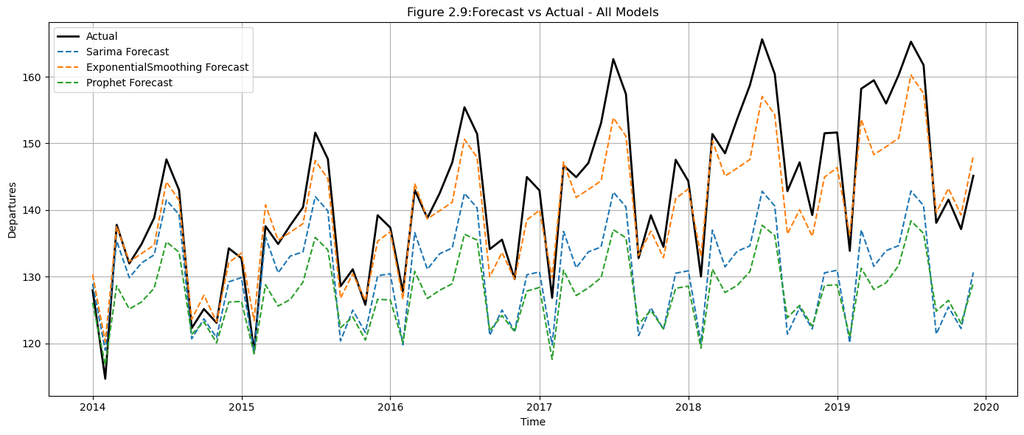

```python
plot_forecasts(test_y, y_preds, models_names_list)
```

```python
# Forecast on training set using the fitted Prophet model
train_len = len(train_y)
future_train = prophet_trained_model.make_future_dataframe(periods=0, freq='MS')
forecast_train = prophet_trained_model.predict(future_train)
y_train_pred = forecast_train['yhat'].iloc[:train_len].values

# Evaluate
mse_train = mean_squared_error(train_y, y_train_pred)
mape_train = mean_absolute_percentage_error(train_y, y_train_pred) * 100

print("\n Prophet Performance on Training Set:")
print(f"MSE: {mse_train:.2f}")
print(f"MAPE: {mape_train:.2f}%")
```

```
 Prophet Performance on Training Set:
MSE: 15.74
MAPE: 3.25%
```

Despite the excellent performance of Prophet on the training set, its significantly higher error on the test set compared to other models may indicate overfitting. While we did not conduct a full hyperparameter optimization, it is likely that tuning Prophet’s regularization parameter (such as changepoint_prior_scale) could improve generalization. Nevertheless, most of the models we tested—particularly Exponential Smoothing and Regression with Fourier terms—demonstrated strong and consistent performance on the test set, achieving very low MSE and MAPE values. The regression-based models will be explored further in the following sections of the work.

### linear trend + seasonality

```python
def plot_preds(y_preds, y_true, title):
    # Plot the results of each model fitting.
    plt.figure(figsize=(10, 6))
    for model_name, y_pred in y_preds.items():
        if model_name == "Linear (with Fourier)":
            plt.plot(y_true.index, y_pred, label=model_name, color='red', linewidth=2.5)
        else:
            plt.plot(y_true.index, y_pred, label=model_name, alpha=0.4, linestyle='--')

    # True values
    plt.plot(y_true, label='True', color='black', linewidth=2)

    # Labels and title
    plt.xlabel('Month in the time series')
    plt.ylabel('Departures')
    plt.title(title)
    plt.legend()
    plt.grid(True)
    plt.tight_layout()
    plt.show()
```

```python
# Train models and compute MSE + MAPE
models = {
    "Linear (no Fourier)": LinearRegression(),
    "Linear (with Fourier)": LinearRegression()
}

y_preds = {}
MSE = {}
MAPE = {}

for name, model in models.items():
    if "no Fourier" in name:
        model.fit(Xb_train, y_train)
        preds = model.predict(Xb_test)
    else:
        model.fit(Xe_train, y_train)
        preds = model.predict(Xe_test)

    y_preds[name] = preds
    MSE[name] = mean_squared_error(y_test, preds)
    MAPE[name] = mean_absolute_percentage_error(y_test, preds) * 100
    print(f"{name} MSE: {MSE[name]:.2f}, MAPE: {MAPE[name]:.2f}%")

# Result table
results_df1 = pd.DataFrame({
    'MSE': MSE,
    'MAPE (%)': MAPE
}).sort_values(by='MSE')
```

```
Linear (no Fourier) MSE: 101.74, MAPE: 5.82%
Linear (with Fourier) MSE: 38.05, MAPE: 3.52%
```

```
MSE: 22.28
MAPE: 2.68%
```

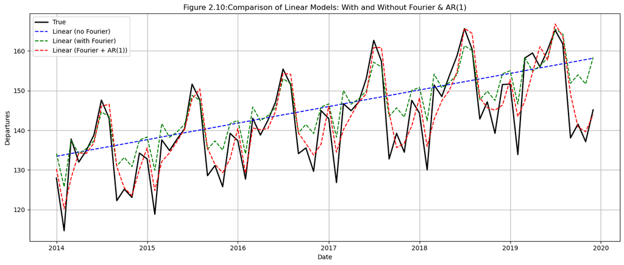

```python
y = monthly_departures['Departures'].values
t = monthly_departures['t'].values
X_seasonality = X_seasonality  # Predefined Fourier terms

y_lag1 = np.roll(y, 1)
y_lag1[:1] = np.nan

X_linear = np.column_stack([np.ones(len(t)), t])
X_ar1 = np.column_stack([X_linear, X_seasonality, y_lag1])
y_target = y.copy()

valid_idx = ~np.isnan(X_ar1).any(axis=1)
X_ar1 = X_ar1[valid_idx]
y_target = y_target[valid_idx]
dates = monthly_departures.index[valid_idx]

split_index = int(len(y_target) * 0.8)
X_train, X_test = X_ar1[:split_index], X_ar1[split_index:]
y_train, y_test = y_target[:split_index], y_target[split_index:]
test_dates = dates[split_index:]

model_ar1 = LinearRegression()
model_ar1.fit(X_train, y_train)
y_pred_ar1 = model_ar1.predict(X_test)

mse = mean_squared_error(y_test, y_pred_ar1)
mape = mean_absolute_percentage_error(y_test, y_pred_ar1) * 100
print(f"MSE: {mse:.2f}")
print(f"MAPE: {mape:.2f}%")

plt.figure(figsize=(14, 6))
x = test_dates

plt.plot(x, y_test, label='True', color='black', linewidth=2)
plt.plot(x, y_preds['Linear (no Fourier)'], label='Linear (no Fourier)', linestyle='--', color='blue')
plt.plot(x, y_preds['Linear (with Fourier)'], label='Linear (with Fourier)', linestyle='--', color='green')
plt.plot(x, y_pred_ar1, label='Linear (Fourier + AR(1))', linestyle='--', color='red')

plt.title("Figure 2.10:Comparison of Linear Models: With and Without Fourier & AR(1)")
plt.xlabel("Date")
plt.ylabel("Departures")
plt.legend()
plt.grid(True)
plt.tight_layout()
plt.show()
```

```python
# Create combined summary table
summary_results = pd.DataFrame(columns=['Model', 'MSE', 'MAPE (%)'])

# Add results from previous tables
summary_results = pd.concat([
    summary_results,
    results_df.reset_index().rename(columns={'index': 'Model'}),
    results_df1.reset_index().rename(columns={'index': 'Model'})
], ignore_index=True)

# Add AR(1) model result
summary_results.loc[len(summary_results)] = {
    'Model': 'Linear (Fourier + AR(1))',
    'MSE': mse,
    'MAPE (%)': mape
}

# Sort by MSE
summary_results = summary_results.sort_values(by='MSE').reset_index(drop=True)

# Display
print(" Combined Model Performance:")
print(summary_results)
```

```
 Combined Model Performance:
                      Model         MSE  MAPE (%)
0      ExponentialSmoothing   19.694172  2.396369
1  Linear (Fourier + AR(1))   22.277165  2.676541
2     Linear (with Fourier)   38.052373  3.522995
3       Linear (no Fourier)  101.741288  5.819154
4                    Sarima  189.175099  8.052918
5                   Prophet  271.579794  9.998873
```

### Part 3 - exogenous data

We selected the CPI indicators for Energy, Transportation, and Gasoline because they are directly related to factors that influence flight activity. Energy and gasoline costs affect airline operational expenses, fuel prices, and ticket pricing. Transportation CPI reflects broader travel costs, including public and private transport demand. By combining these variables, we aim to capture both the cost-side and demand-side drivers that can help explain changes in the volume of flight departures.

```python
# 1. Create individual CPI series from the loaded df
energy_df = df[['CPI_Energy']].rename(columns={'CPI_Energy': 'value'}).copy().reset_index()
transportation_df = df[['CPI_Transport']].rename(columns={'CPI_Transport': 'value'}).copy().reset_index()
gasoline_df = df[['CPI_Gasoline']].rename(columns={'CPI_Gasoline': 'value'}).copy().reset_index()
```

```python
# List of CPI columns to check
cpi_columns = ['CPI_Energy', 'CPI_Transport', 'CPI_Gasoline']

# Count missing values per column
print("Missing values per CPI column:\n")
for col in cpi_columns:
    missing_count = df[col].isna().sum()
    print(f"{col}: {missing_count} missing values")
```

```
Missing values per CPI column:

CPI_Energy: 36 missing values
CPI_Transport: 0 missing values
CPI_Gasoline: 0 missing values
```

Since the CPI Energy series contains no data at all between 1990 and 1992, we considered three options for handling the missing values: (1) filling with zeros, (2) discarding the entire energy series,(3) imputing the missing values based on the first available observation in January 1993. Filling with zeros was ruled out because CPI is a relative index, and inserting zeros would drastically distort the scale and reduce the overall level of the series. Discarding the series altogether would result in the loss of a potentially meaningful explanatory variable. Therefore, we chose to fill the missing entries from 1990 to 1992 using the value from January 1993, assuming that the early values were relatively stable and comparable to the earliest available data point. This approach preserves continuity in the dataset while minimizing distortion.

```python
# 2. Fill missing values in Energy CPI between Jan 1990 and Dec 1992 using Jan 1993 as reference
ref_value = energy_df.loc[energy_df['date'] == '1993-01-01', 'value'].values[0]

# Define missing date range
missing_dates = pd.date_range(start='1990-01-01', end='1992-12-01', freq='MS')
missing_df = pd.DataFrame({
    'date': missing_dates,
    'value': ref_value
})

# Remove overlaps (if any) and concatenate
energy_df_clean = energy_df[~energy_df['date'].isin(missing_dates)]
energy_df = pd.concat([missing_df, energy_df_clean], ignore_index=True).sort_values('date').reset_index(drop=True)

# 3. Final check – make sure all dataframes are ready
print(energy_df.head(3))
print(transportation_df.head(3))
print(gasoline_df.head(3))
```

```
        date  value
0 1990-01-01   84.1
1 1990-02-01   84.1
2 1990-03-01   84.1
        date  value
0 1990-01-01  117.0
1 1990-02-01  117.2
2 1990-03-01  117.3
        date  value
0 1990-01-01  153.5
1 1990-02-01  154.3
2 1990-03-01  155.2
```

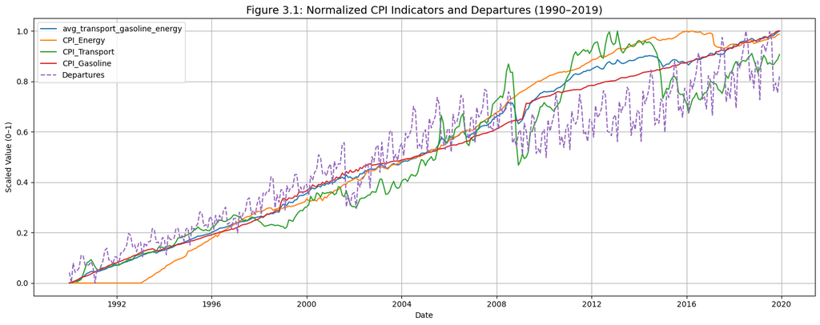

```python
# Merge CPI series and calculateaverage
merged_all = pd.merge(
    transportation_df[['date', 'value']],
    gasoline_df[['date', 'value']],
    on='date',
    suffixes=('_transport', '_gasoline')
)

merged_all = pd.merge(
    merged_all,
    energy_df[['date', 'value']],
    on='date'
).rename(columns={'value': 'value_energy'})

merged_all['avg_transport_gasoline_energy'] = merged_all[
    ['value_transport', 'value_gasoline', 'value_energy']
].mean(axis=1)

monthly_departures.index = pd.to_datetime(monthly_departures.index)
departures_df = monthly_departures.reset_index().rename(columns={'index': 'date'})

# Build combined DataFrame
combined_df = merged_all[['date', 'avg_transport_gasoline_energy']].copy()

combined_df = combined_df.merge(energy_df[['date', 'value']], on='date', how='left')
combined_df = combined_df.rename(columns={'value': 'CPI_Energy'})

combined_df = combined_df.merge(transportation_df[['date', 'value']], on='date', how='left')
combined_df = combined_df.rename(columns={'value': 'CPI_Transport'})

combined_df = combined_df.merge(gasoline_df[['date', 'value']], on='date', how='left')
combined_df = combined_df.rename(columns={'value': 'CPI_Gasoline'})

# Add departures column
combined_df = combined_df.merge(departures_df[['date', 'Departures']], on='date', how='inner')
combined_df = combined_df.rename(columns={'Departures': 'Departures'})

# Normalize all columns except date
scaler = MinMaxScaler()
scaled_values = scaler.fit_transform(combined_df.drop(columns='date'))
scaled_df = pd.DataFrame(scaled_values, columns=combined_df.columns[1:], index=combined_df['date'])

plt.figure(figsize=(15, 6))

for col in scaled_df.columns:
    linestyle = '--' if col == 'Departures' else '-'
    plt.plot(scaled_df.index, scaled_df[col], label=col, linestyle=linestyle)

plt.title("Figure 3.1: Normalized CPI Indicators and Departures (1990–2019)", fontsize=14)
plt.xlabel("Date")
plt.ylabel("Scaled Value (0–1)")
plt.legend(loc='upper left')
plt.grid(True)
plt.tight_layout()
plt.show()
```

```python
# Add average column for combined CPI
combined_df['avg_transport_gasoline_energy'] = combined_df[
    ['CPI_Energy', 'CPI_Transport', 'CPI_Gasoline']
].mean(axis=1)

exog_variables = ['CPI_Energy', 'CPI_Transport', 'CPI_Gasoline', 'avg_transport_gasoline_energy']
results = []

for exog_var in exog_variables:
    print(f"Running SARIMA with exogenous variable: {exog_var}")

    df = combined_df[['Departures', exog_var]].dropna()

    # Train/test split
    split_ratio = 0.8
    split_index = int(len(df) * split_ratio)
    train_y = df['Departures'].iloc[:split_index]
    test_y = df['Departures'].iloc[split_index:]
    train_exog = df[[exog_var]].iloc[:split_index]
    test_exog = df[[exog_var]].iloc[split_index:]

    # SARIMAX with one exogenous variable
    model = SARIMAX(train_y, exog=train_exog, order=(2, 0, 0), seasonal_order=(1, 1, 0, 12))
    fitted_model = model.fit(disp=False)
    forecast = fitted_model.forecast(steps=len(test_y), exog=test_exog)

    # Evaluation metrics
    mse = mean_squared_error(test_y, forecast)
    mape = mean_absolute_percentage_error(test_y, forecast) * 100
    results.append((exog_var, mse, mape))

results_df = pd.DataFrame(results, columns=['Exogenous Variable', 'MSE', 'MAPE (%)'])
results_df = results_df.sort_values(by='MSE')

print("\n MSE & MAPE by Exogenous Variable:")
print(results_df)
```

```
Running SARIMA with exogenous variable: CPI_Energy
Running SARIMA with exogenous variable: CPI_Transport
Running SARIMA with exogenous variable: CPI_Gasoline
Running SARIMA with exogenous variable: avg_transport_gasoline_energy

 MSE & MAPE by Exogenous Variable:
              Exogenous Variable         MSE  MAPE (%)
0                     CPI_Energy  114.593500  6.243054
2                   CPI_Gasoline  182.614331  7.917291
3  avg_transport_gasoline_energy  185.475302  8.146976
1                  CPI_Transport  213.736219  8.749718
```

```python
print("\n Training SARIMA without exogenous variables...")

# Train/test split
split_ratio = 0.8
split_index = int(len(monthly_departures) * split_ratio)
train_df = monthly_departures.iloc[:split_index]
train_y = train_df['Departures']
test_df = monthly_departures.iloc[split_index:]
test_y = test_df['Departures']

# Basic SARIMA model without exogenous variables
model = SARIMAX(train_y, order=(2, 0, 0), seasonal_order=(1, 1, 0, 12))
fitted_model = model.fit(disp=False)
forecast = fitted_model.forecast(steps=len(test_y))

# Evaluation
mse = mean_squared_error(test_y, forecast)
mape = mean_absolute_percentage_error(test_y, forecast) * 100
print(f" SARIMA without exog done. MSE = {mse:.2f}, MAPE = {mape:.2f}%")

# Add to existing results table
results_df = pd.concat([
    results_df,
    pd.DataFrame([['SARIMA (no exog)', mse, mape]], columns=['Exogenous Variable', 'MSE', 'MAPE (%)'])
], ignore_index=True)

# Sort by MSE
results_df = results_df.sort_values(by='MSE')

print("\n Final comparison including SARIMA without exog:")
print(results_df)
```

```
 Training SARIMA without exogenous variables...
 SARIMA without exog done. MSE = 189.18, MAPE = 8.05%

 Final comparison including SARIMA without exog:
              Exogenous Variable         MSE  MAPE (%)
0                     CPI_Energy  114.593500  6.243054
1                   CPI_Gasoline  182.614331  7.917291
2  avg_transport_gasoline_energy  185.475302  8.146976
4               SARIMA (no exog)  189.175099  8.052918
3                  CPI_Transport  213.736219  8.749718
```

```python
def plot_exog_vs_base_sarima(test_y, y_preds_exog, base_sarima_forecast, title="SARIMA Forecasts Comparison"):
    plt.figure(figsize=(15, 6))
    x = test_y.index

    # Actual values
    plt.plot(x, test_y, label='Actual', color='black', linewidth=2)

    # SARIMA without exogenous variables
    plt.plot(x, base_sarima_forecast, label='SARIMA (No exog)', color='gray', linestyle='--')

    # SARIMA with each exogenous variable
    for exog_name, forecast in y_preds_exog.items():
        plt.plot(x, forecast, label=f"SARIMA + {exog_name}", linestyle='--')

    # Style
    plt.title("Figure 3.2:"+title)
    plt.xlabel("Date")
    plt.ylabel("Departures")
    plt.legend()
    plt.grid(True)
    plt.tight_layout()
    plt.show()
```

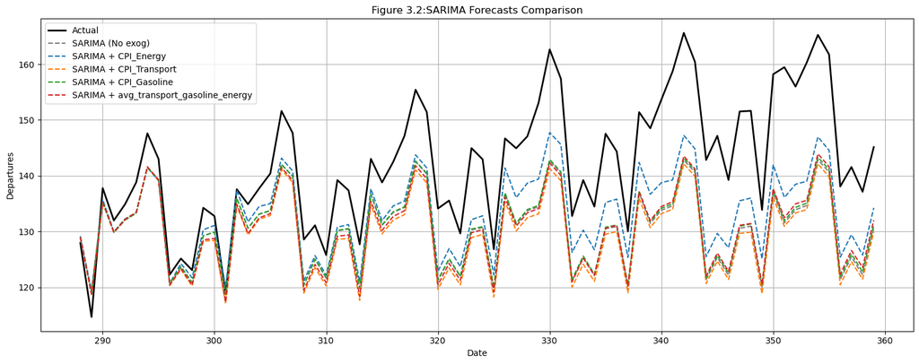

```python
exog_variables = ['CPI_Energy', 'CPI_Transport', 'CPI_Gasoline', 'avg_transport_gasoline_energy']

# Initialize
y_preds_exog = {}
test_y = None
sarima_forecast = None

# SARIMA with each exogenous variable
for exog_var in exog_variables:
    df = combined_df[['Departures', exog_var]].dropna()
    split_index = int(len(combined_df) * 0.8)

    train_y = combined_df['Departures'].iloc[:split_index]
    test_y = combined_df['Departures'].iloc[split_index:]
    train_exog = combined_df[[exog_var]].iloc[:split_index]
    test_exog = combined_df[[exog_var]].iloc[split_index:]

    model = SARIMAX(train_y, exog=train_exog, order=(2, 0, 0), seasonal_order=(1, 1, 0, 12))
    fitted = model.fit(disp=False)
    forecast = fitted.forecast(steps=len(test_y), exog=test_exog)

    y_preds_exog[exog_var] = forecast

# SARIMA without exogenous variables
df_base = combined_df[['Departures']].dropna()
split_index = int(len(df_base) * 0.8)
train_y = df_base['Departures'].iloc[:split_index]
test_y = df_base['Departures'].iloc[split_index:]

model = SARIMAX(train_y, order=(2, 0, 0), seasonal_order=(1, 1, 0, 12))
fitted = model.fit(disp=False)
sarima_forecast = fitted.forecast(steps=len(test_y))

# Plot comparison
plot_exog_vs_base_sarima(test_y, y_preds_exog, sarima_forecast)
```

### exogenous data with fourier and Regression

```python
exog_vars_list = [
    None,
    ['CPI_Energy'],
    ['CPI_Transport'],
    ['CPI_Gasoline'],
    ['avg_transport_gasoline_energy'],
]

results = []
y_preds_dict = {}

# Create lag feature
y_lag1 = np.roll(y, 1)
y_lag1[0] = np.nan

for exog_vars in exog_vars_list:
    if exog_vars is None:
        print(" Training with NO exogenous variables")
        X_base = np.concatenate([X_linear, X_seasonality], axis=1)
        label = 'Fourier + AR(1)'
    else:
        print(f" Training with exogenous variables: {exog_vars}")
        X_exog = combined_df[exog_vars].values
        X_base = np.concatenate([X_linear, X_seasonality, X_exog], axis=1)
        label = f"Fourier + AR(1) + {' + '.join(exog_vars)}"

    X_total = np.column_stack([X_base, y_lag1])
    valid_idx = ~np.isnan(X_total).any(axis=1)
    X_valid = X_total[valid_idx]
    y_valid = y[valid_idx]

    split_idx = int(len(y_valid) * 0.8)
    X_train, X_test = X_valid[:split_idx], X_valid[split_idx:]
    y_train, y_test = y_valid[:split_idx], y_valid[split_idx:]

    model = LinearRegression()
    model.fit(X_train, y_train)
    y_pred = model.predict(X_test)

    y_preds_dict[label] = y_pred

    mse = mean_squared_error(y_test, y_pred)
    mape = mean_absolute_percentage_error(y_test, y_pred) * 100
    results.append((label, mse, mape))

# Summary table
results_df = pd.DataFrame(results, columns=['Model', 'MSE', 'MAPE (%)']).sort_values(by='MSE')
print(results_df)
```

```
 Training with NO exogenous variables
 Training with exogenous variables: ['CPI_Energy']
 Training with exogenous variables: ['CPI_Transport']
 Training with exogenous variables: ['CPI_Gasoline']
 Training with exogenous variables: ['avg_transport_gasoline_energy']
                                             Model        MSE  MAPE (%)
0                                  Fourier + AR(1)  22.277165  2.676541
3                   Fourier + AR(1) + CPI_Gasoline  23.162465  2.733909
2                  Fourier + AR(1) + CPI_Transport  23.734862  2.766375
4  Fourier + AR(1) + avg_transport_gasoline_energy  34.331349  3.404959
1                     Fourier + AR(1) + CPI_Energy  35.484918  3.342692
```

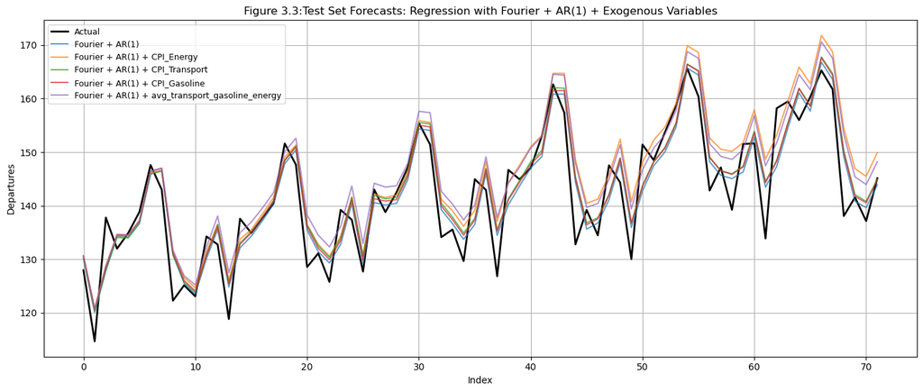

```python
plt.figure(figsize=(14, 6))

# Plot actual values
plt.plot(np.arange(len(y_test)), y_test, label='Actual', color='black', linewidth=2)

# Plot predictions from all models
for label, y_pred in y_preds_dict.items():
    plt.plot(np.arange(len(y_pred)), y_pred, label=label, alpha=0.7)

plt.title("Figure 3.3:Test Set Forecasts: Regression with Fourier + AR(1) + Exogenous Variables")
plt.xlabel("Index")
plt.ylabel("Departures")
plt.legend(loc='upper left', fontsize=9)
plt.grid(True)
plt.tight_layout()
plt.show()
```

### part 4

### The Shewhart Control Chart

To identify the most suitable SARIMA model for further analysis, including potential structural break tests, we evaluated a set of models with and without exogenous variables. Specifically, we considered CPI indicators such as Energy, Transportation, Gasoline, and their combined average as exogenous regressors. Each model was fitted on the full dataset without a train-test split, and the Bayesian Information Criterion (BIC) was used as the selection metric. The model with the lowest BIC was selected as the best-fitting model, indicating the most efficient balance between goodness-of-fit and model complexity.

```python
# Create average variable from the CPI series
combined_df['avg_transport_gasoline_energy'] = combined_df[
    ['CPI_Energy', 'CPI_Transport', 'CPI_Gasoline']
].mean(axis=1)

# Exogenous variables to test
exog_variables = ['CPI_Energy', 'CPI_Transport', 'CPI_Gasoline', 'avg_transport_gasoline_energy', None]

results = []
best_bic = float('inf')
best_model = None
best_label = ""

for exog_var in exog_variables:
    label = exog_var if exog_var is not None else 'No Exogenous Variable'
    print(f"Training SARIMA on full data with: {label}")

    if exog_var is not None:
        df = combined_df[['Departures', exog_var]].dropna()
        exog = df[[exog_var]]
    else:
        df = combined_df[['Departures']].dropna()
        exog = None

    y = df['Departures']

    # Fit SARIMA on full data
    model = SARIMAX(y, exog=exog, order=(2, 0, 0), seasonal_order=(1, 1, 0, 12))
    fitted_model = model.fit(disp=False)

    bic = fitted_model.bic
    results.append((label, bic))

    if bic < best_bic:
        best_bic = bic
        best_model = fitted_model
        best_label = label

# Display results
results_df = pd.DataFrame(results, columns=['Model', 'BIC']).sort_values(by='BIC')
print("\nSARIMA Model BIC Comparison:")
print(results_df)

print(f"\n Best model by BIC: {best_label} (BIC = {best_bic:.2f})")
```

```
Training SARIMA on full data with: CPI_Energy
Training SARIMA on full data with: CPI_Transport
Training SARIMA on full data with: CPI_Gasoline
Training SARIMA on full data with: avg_transport_gasoline_energy
Training SARIMA on full data with: No Exogenous Variable

SARIMA Model BIC Comparison:
                           Model          BIC
4          No Exogenous Variable  1695.621102
1                  CPI_Transport  1700.844353
3  avg_transport_gasoline_energy  1700.868276
0                     CPI_Energy  1701.378532
2                   CPI_Gasoline  1701.460299

 Best model by BIC: No Exogenous Variable (BIC = 1695.62)
```

```
Dates with out-of-control residuals:
Index(['09 2001', '10 2002', '05 2009'], dtype='object', name='date')
```

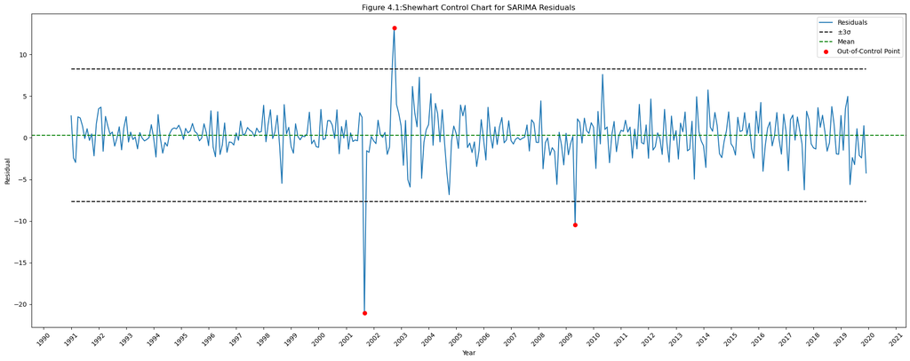

```python
# Create DataFrame with SARIMA residuals and ensure datetime index
res_plot = pd.DataFrame(model_AR2s.resid.iloc[12:], columns=['error'])

# If index is not datetime, create a monthly date range
if not isinstance(res_plot.index, pd.DatetimeIndex):
    res_plot.index = pd.date_range(start="1990-01-01", periods=len(res_plot), freq='MS')

res_plot['date'] = res_plot.index

# Compute control limits
res_mean = res_plot['error'].mean()
res_std = res_plot['error'].std()
ucl = res_mean + 3 * res_std
lcl = res_mean - 3 * res_std

# Identify out-of-control residuals
out_of_control = res_plot[(res_plot['error'] > ucl) | (res_plot['error'] < lcl)]

print("Dates with out-of-control residuals:")
print(out_of_control.index.strftime('%m %Y'))

# Plot Shewhart control chart
plt.figure(figsize=(20, 8))
plt.plot(res_plot['date'], res_plot['error'], label='Residuals')
plt.hlines([ucl, lcl], res_plot['date'].min(), res_plot['date'].max(),
           linestyles='dashed', colors='black', label='±3σ')
plt.axhline(res_mean, color='green', linestyle='--', label='Mean')
plt.scatter(out_of_control['date'], out_of_control['error'], color='red', label='Out-of-Control Point', zorder=5)

# Format x-axis
plt.gca().xaxis.set_major_locator(mdates.YearLocator())
plt.gca().xaxis.set_major_formatter(mdates.DateFormatter('%Y'))

plt.title("Figure 4.1:Shewhart Control Chart for SARIMA Residuals")
plt.xlabel("Year")
plt.ylabel("Residual")
plt.legend()
plt.xticks(rotation=45)
plt.tight_layout()
plt.show()
```